# NEON Lidar Data

Megan Cattau

June 18, 2016

## Megan Cattau Bio

I am a **forest and landscape ecologist** who explores how anthropogenic factors affect disturbance dynamics in order to inform **conservation and land management** decisions. I have just joined the University of Colorado Department of Geography and the Earth Lab as a postdoc to examine forest health and analyze what is driving Colorado forest dieback. I’ll be integrating datasets on canopy structure and loss, drought, beetle kill, fire dynamics, and field-based surveys of forest structure to identify convergence and divergence of disturbance events, cross-scale interactions, and consequent ecosystem response. In addition, I will use these data sources to guide targeted observations of forest properties detected from a suite of sensors on unmanned aerial systems.

## Capstone Project

I am interested in characterizing the structure of vegetative regrowth after fire disturbance. For this objective, I would use the NEON Airborne Observation Platform (AOP) data, combined with fire hotspot locations derived from MODIS. For the study area, I would use one of the sites for which LiDAR data is available (e.g., D03). Another option if this proves to be too complicated would be to characterize the structural habitat requirements of a species of interest. I would use climate data (Worldclim) and AOP data as predictors sampled at species occurrence points from GBIF in a species distribution model (Bioclim, GLM, or Maxent).

# Week 3 Activity

This exercise demonstrates using some of the LiDAR data products collected over Lower Teakettle, a NEON relocatable field site in California

We will first load the required packages for this exercise, including rgdal and raster, and set the working directory.

```r
library(rgdal)
library(raster)
# set working directory
setwd("/Users/megancattau/Documents/data/NEONDI-2016/")
```

We will then load our first raster dataset, TEAK_lidarDSM, the digital surface model (DSM).

```r
# import dsm
teak_dsm <- raster("NEONdata/D17-California/TEAK/2013/lidar/TEAK_lidarDSM.tif")
```

We will visualize this data by plotting it.

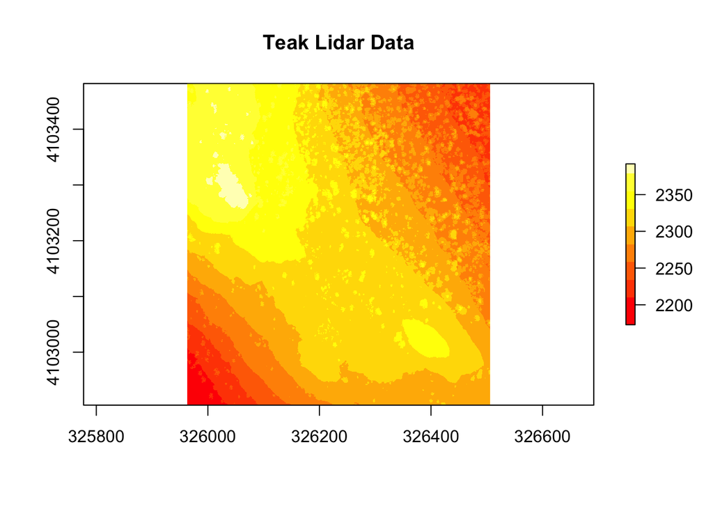

```r
# plot dsm
plot(teak_dsm, col=heat.colors(10), main="Teak Lidar Data")
```

Next, we will import the TEAK_lidarCHM data, the canopy height, and plot it.

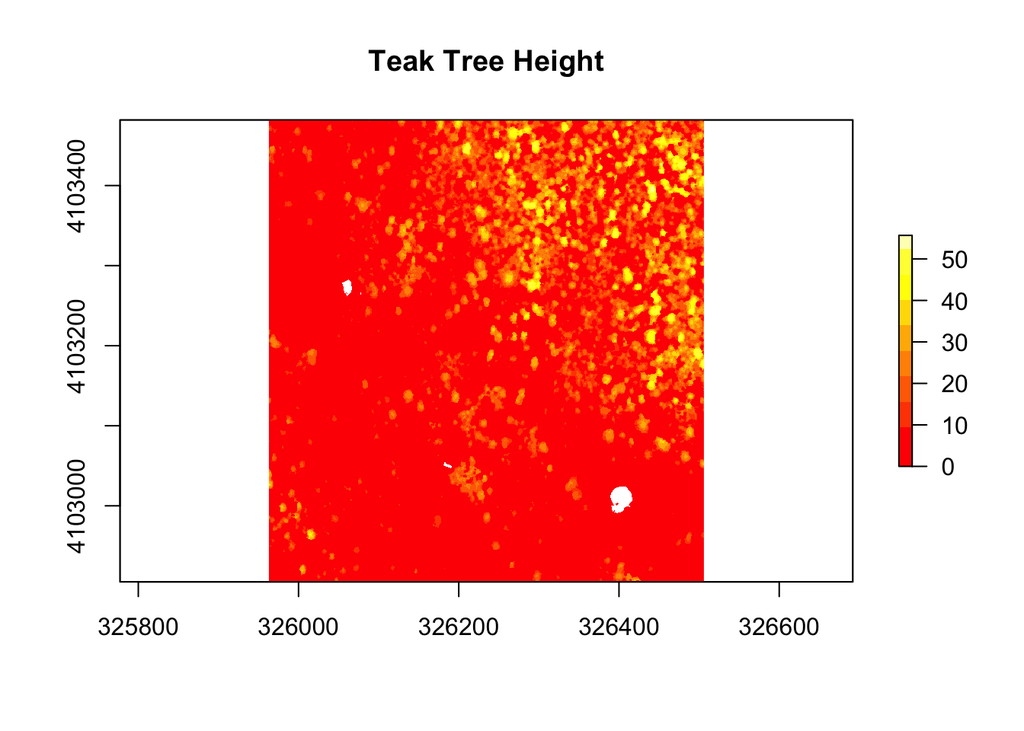

```r
# import raster
teak_CHM <- raster("NEONdata/D17-California/TEAK/2013/lidar/TEAK_lidarCHM.tif")

# plot raster
plot(teak_CHM, col=heat.colors(10), main="Teak Tree Height")
```

We will explore the data by creating histograms for both rasters.

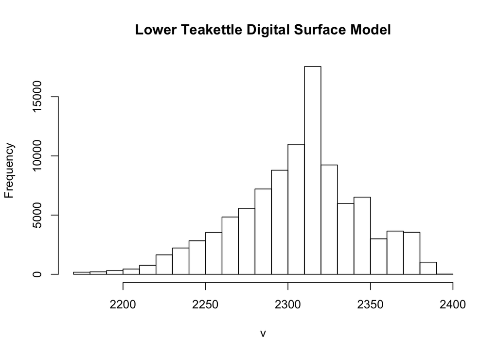

```r
# histogram dsm
hist(teak_dsm, main="Lower Teakettle Digital Surface Model")
```

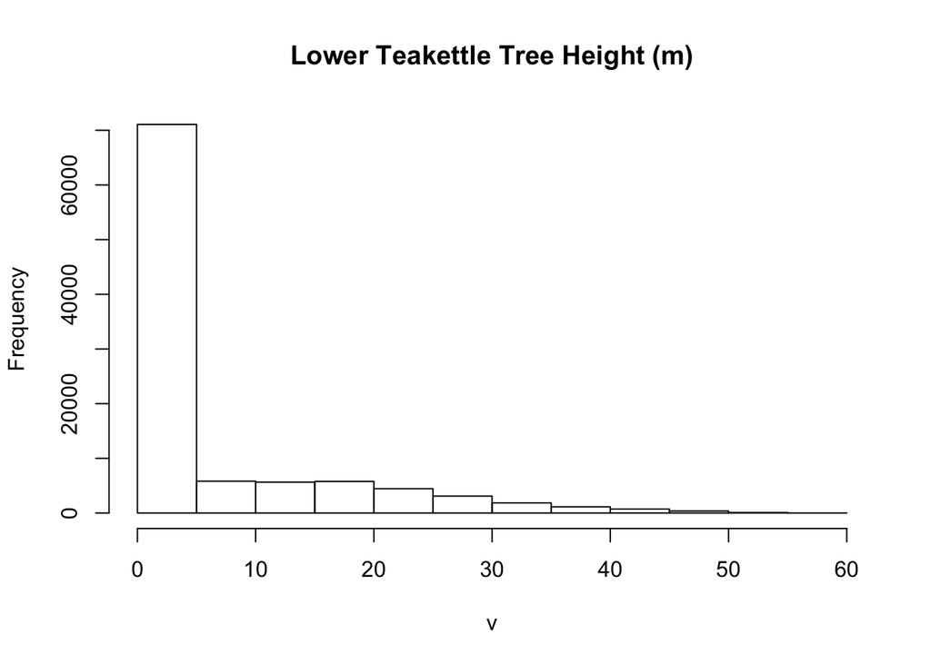

```r
# histogram slope
hist(teak_CHM, main="Lower Teakettle Tree Height (m)")
```

We will look at the relationship between dsm and tree height by plotting these rasters against one another.

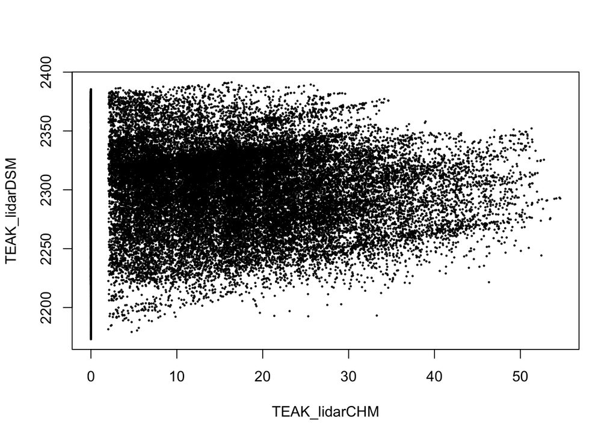

```r
# plot dsm and tree height
plot(teak_CHM, teak_dsm)
```